# Homework10_SDS315

Caroline Zhuang

[output not shown]

# **Problem 1**

```
##  (Intercept)     minority         fire          age       income
## -0.124873055  0.008358545  0.021739334  0.005623392 -0.015964782
```

- Question: Is there an association between the number of FAIR policies and racial composition of ZIP code, factoring in the fire, age, and income variables?
- Approach: To answer the question, I used a linear regression model with policies being the y variable and minority, fire, age, and income being the x variables.
- Results: The intercept is -0.125. As minority percentage increases, the number of policies increase by 0.008. As fires increase, policies increase by 0.022. For every increase in percent of housing units built before WWII, the policies increase by 0.006. For every increase in income, the policies decrease by 0.016.
- Conclusion: While minority percentages play a role in the number of policies, the number of fires per 100 housing units factors in more to the number of policies as the coefficient is higher. This means in neighborhoods where there are more fires, there is less access to the private market. Whereas the rest of the variables have positive coefficients, as income increases, the number of policies decrease. This means neighborhoods with higher incomes have more access to the private market.

# **Problem 2**

## **Part A**

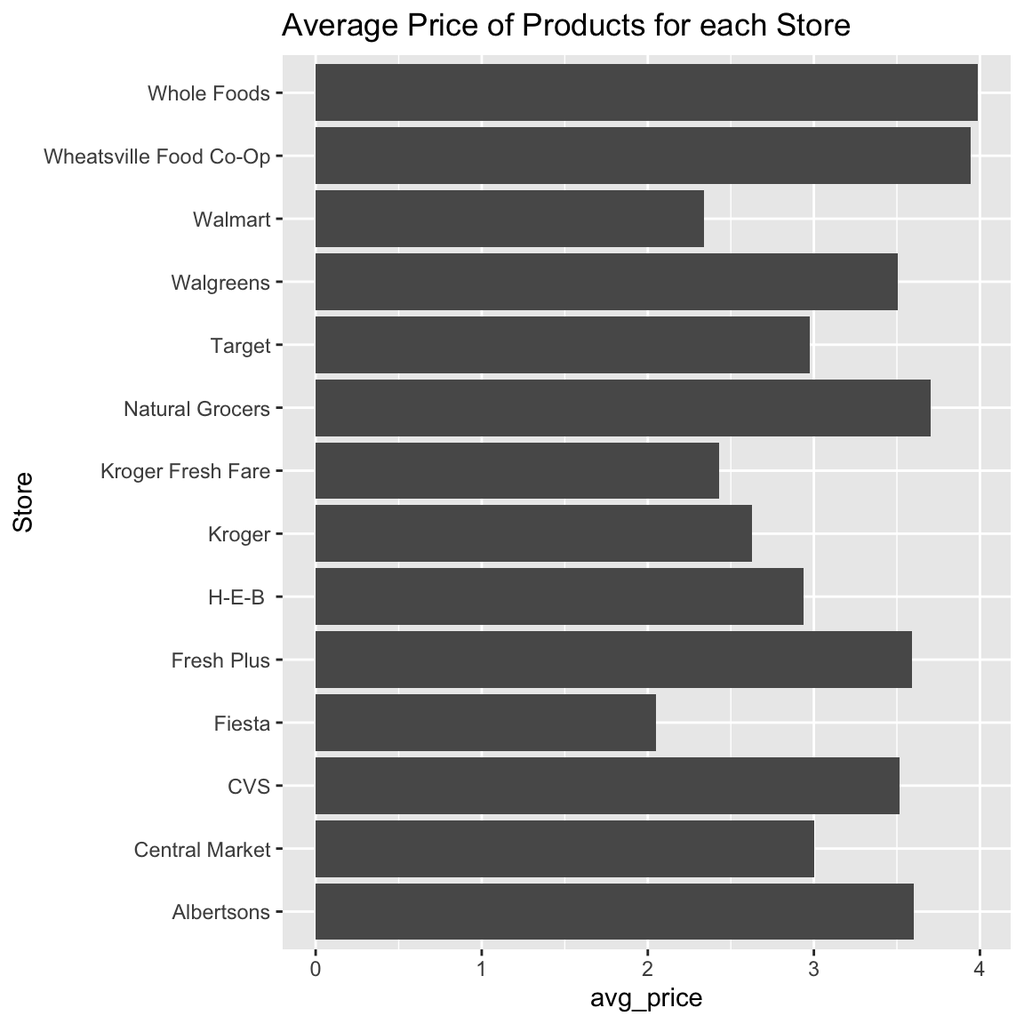

The bar graph above shows the average price of products sold at each store.

## **Part B**

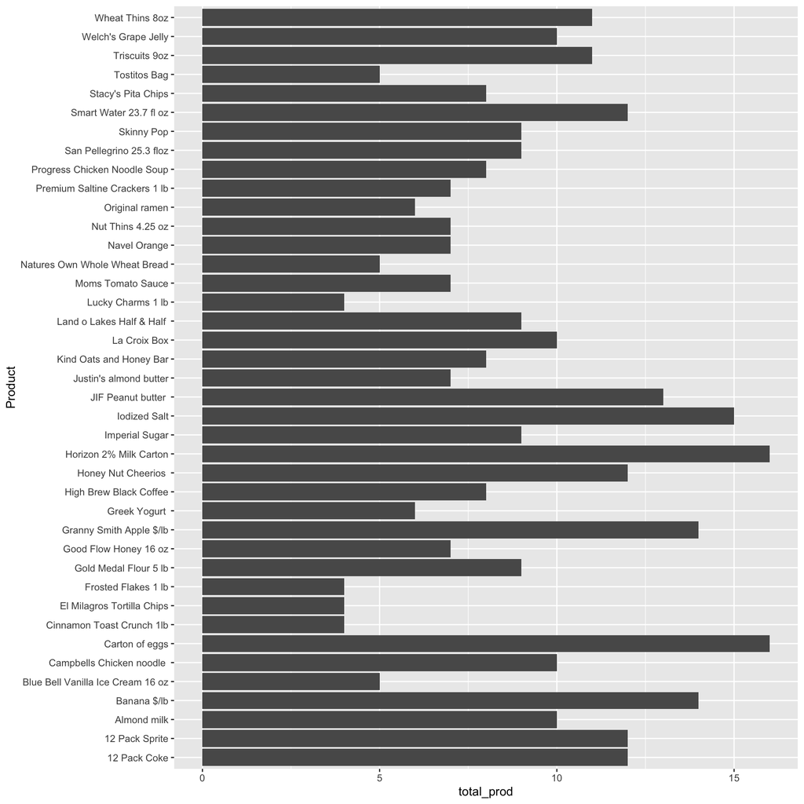

The bar graph above shows the amount of stores that sell each product. For example, 16 stores sell a carton of eggs.

## **Part C**

```
##                                               2.5 %        97.5 %
## (Intercept)                               5.4461802  6.4011154524
## TypeGrocery                              -0.9154098 -0.4131031458
## TypeHigh-end Grocery                     -0.5944834 -0.0008968566
## TypeNatural                              -0.4037250  0.2192581912
## TypeSmall Format                         -0.7454724 -0.1428388392
## Product12 Pack Sprite                    -0.6340950  0.5974283379
## ProductAlmond milk                       -2.8525515 -1.5573896506
## ProductBanana $/lb                       -5.4799319 -4.2894146000
## ProductBlue Bell Vanilla Ice Cream 16 oz -3.7520923 -2.1421358570
## ProductCampbells Chicken noodle          -4.1115515 -2.8163896506
## ProductCarton of eggs                    -3.5774725 -2.4241176770
## ProductCinnamon Toast Crunch 1lb         -1.8696613 -0.1241717453
## ProductEl Milagros Tortilla Chips        -2.9129671 -1.1651607441
## ProductFrosted Flakes 1 lb               -2.1246613 -0.3791717453
## ProductGold Medal Flour 5 lb             -2.8372300 -1.5046125814
## ProductGood Flow Honey 16 oz              0.2808176  1.7240341201
## ProductGranny Smith Apple $/lb           -4.3199319 -3.1294146000
## ProductGreek Yogurt                      -4.6079636 -3.0970491791
## ProductHigh Brew Black Coffee            -3.6121524 -2.2295143472
## ProductHoney Nut Cheerios                -2.3416352 -1.1094592274
## ProductHorizon 2% Milk Carton            -1.6774725 -0.5241176770
## ProductImperial Sugar                    -3.1483411 -1.8157236926
## ProductIodized Salt                      -4.4512391 -3.2812048876
## ProductJIF Peanut butter                 -3.3245622 -2.1168826179
## ProductJustin's almond butter             6.0836747  7.5268912630
## ProductKind Oats and Honey Bar           -2.5550655 -1.1701652933
## ProductLa Croix Box                      -1.7195515 -0.4243896506
## ProductLand o Lakes Half & Half          -3.9644300 -2.6289732430
## ProductLucky Charms 1 lb                 -2.3746613 -0.6291717453
## ProductMoms Tomato Sauce                  0.7236747  2.1668912630
## ProductNatures Own Whole Wheat Bread     -3.2238381 -1.6152736311
## ProductNavel Orange                      -4.6806110 -3.2373944513
## ProductNut Thins 4.25 oz                 -3.1963253 -1.7531087370
## ProductOriginal ramen                    -5.8118874 -4.3004408731
## ProductPremium Saltine Crackers 1 lb     -3.0518795 -1.6146755310
## ProductProgress Chicken Noodle Soup      -3.7593438 -2.3812397045
## ProductSan Pellegrino 25.3 floz          -4.3177633 -2.9823065764
## ProductSkinny Pop                        -2.7046528 -1.3717357209
## ProductSmart Water 23.7 fl oz            -4.3084790 -3.0761838276
## ProductStacy's Pita Chips                -2.4986751 -1.1174141159
## ProductTostitos Bag                      -2.4860923 -0.8761358570
## ProductTriscuits 9oz                     -2.8861621 -1.6263080570
## ProductWelch's Grape Jelly               -3.5819230 -2.2890645533
## ProductWheat Thins 8oz                   -2.8952530 -1.6353989661
```

Compared with ordinary grocery stores (like Albertsons, HEB, or Krogers), convenience stores charge somewhere between 0.41 and 0.92 dollars more for the same product.

## **Part D**

```
##                                                2.5 %       97.5 %
## (Intercept)                               5.29481829  6.214523748
## Product12 Pack Sprite                    -0.58263797  0.545971300
## ProductAlmond milk                       -2.88979207 -1.696147469
## ProductBanana $/lb                       -5.40393837 -4.309933984
## ProductBlue Bell Vanilla Ice Cream 16 oz -3.81973745 -2.336193387
## ProductCampbells Chicken noodle          -4.14879207 -2.955147469
## ProductCarton of eggs                    -3.51080489 -2.451075642
## ProductCinnamon Toast Crunch 1lb         -1.97850431 -0.368091042
## ProductEl Milagros Tortilla Chips        -2.72058833 -1.100408677
## ProductFrosted Flakes 1 lb               -2.23350431 -0.623091042
## ProductGold Medal Flour 5 lb             -2.86004284 -1.629897962
## ProductGood Flow Honey 16 oz              0.23900798  1.569432416
## ProductGranny Smith Apple $/lb           -4.24393837 -3.149933984
## ProductGreek Yogurt                      -4.62930236 -3.233844060
## ProductHigh Brew Black Coffee            -3.65021535 -2.374937874
## ProductHoney Nut Cheerios                -2.24361184 -1.113052020
## ProductHorizon 2% Milk Carton            -1.61080489 -0.551075642
## ProductImperial Sugar                    -3.21104464 -1.983667913
## ProductIodized Salt                      -4.39282443 -3.317353240
## ProductJIF Peanut butter                 -3.18794602 -2.077268441
## ProductJustin's almond butter             6.04186513  7.372289559
## ProductKind Oats and Honey Bar           -2.53297768 -1.257953650
## ProductLa Croix Box                      -1.75679207 -0.563147469
## ProductLand o Lakes Half & Half          -3.99630165 -2.765564195
## ProductLucky Charms 1 lb                 -2.48350431 -0.873091042
## ProductMoms Tomato Sauce                  0.68186513  2.012289559
## ProductNatures Own Whole Wheat Bread     -3.17207699 -1.685423804
## ProductNavel Orange                      -4.72242059 -3.391996155
## ProductNut Thins 4.25 oz                 -3.23813487 -1.907710441
## ProductOriginal ramen                    -5.89711766 -4.504479380
## ProductPremium Saltine Crackers 1 lb     -3.05683364 -1.730616540
## ProductProgress Chicken Noodle Soup      -3.77416621 -2.502678040
## ProductSan Pellegrino 25.3 floz          -4.34963499 -3.118897529
## ProductSkinny Pop                        -2.79946086 -1.571297623
## ProductSmart Water 23.7 fl oz            -4.22335959 -3.091052907
## ProductStacy's Pita Chips                -2.54783030 -1.275605236
## ProductTostitos Bag                      -2.55373745 -1.070193387
## ProductTriscuits 9oz                     -2.70212738 -1.541077829
## ProductWelch's Grape Jelly               -3.41187152 -2.224069988
## ProductWheat Thins 8oz                   -2.71121828 -1.550168738
## StoreCentral Market                      -0.92164719 -0.225125837
## StoreCVS                                 -0.16684400  0.553068808
## StoreFiesta                              -1.23351226 -0.172951704
## StoreFresh Plus                          -0.35487988  0.282551136
## StoreH-E-B                               -0.94513262 -0.346786025
## StoreKroger                              -1.16242453 -0.244211765
## StoreKroger Fresh Fare                   -1.36088607 -0.442673303
## StoreNatural Grocers                     -0.46989988  0.307540177
## StoreTarget                              -0.74706831  0.000328972
## StoreWalgreens                           -0.14031581  0.571282360
## StoreWalmart                             -1.45165530 -0.533442534
## StoreWheatsville Food Co-Op              -0.06146201  0.642048073
## StoreWhole Foods                          0.01672253  0.711594471
```

From the confidence intervals above, the two stores charging the highest prices are Whole Foods and Wheatsville Food Co-Op.

## **Part E**

From my model in Part D, Central Market seems to charge a similar amount to HEB for the same product. HEB has a confidence interval of -0.95 to -0.35 while Central Market has an interval between -0.92 and -0.23. The difference between these stores is a lot less than the difference between a store like Whole Foods and HEB.

## **Part F**

```
##                              (Intercept)
##                                    5.616
##                                income10k
##                                   -0.014
##                    Product12 Pack Sprite
##                                   -0.018
##                       ProductAlmond milk
##                                   -2.114
##                       ProductBanana $/lb
##                                   -4.908
## ProductBlue Bell Vanilla Ice Cream 16 oz
##                                   -2.908
##         ProductCampbells Chicken noodle
##                                   -3.373
##                    ProductCarton of eggs
##                                   -2.974
##         ProductCinnamon Toast Crunch 1lb
##                                   -1.195
##        ProductEl Milagros Tortilla Chips
##                                   -2.000
##               ProductFrosted Flakes 1 lb
##                                   -1.450
##             ProductGold Medal Flour 5 lb
##                                   -2.099
##             ProductGood Flow Honey 16 oz
##                                    1.056
##           ProductGranny Smith Apple $/lb
##                                   -3.748
##                     ProductGreek Yogurt
##                                   -3.917
##            ProductHigh Brew Black Coffee
##                                   -2.823
##               ProductHoney Nut Cheerios
##                                   -1.695
##            ProductHorizon 2% Milk Carton
##                                   -1.074
##                    ProductImperial Sugar
##                                   -2.416
##                      ProductIodized Salt
##                                   -3.838
```

[output cut: 27 more lines]

```
##                                   -3.524
##                        ProductSkinny Pop
##                                   -1.953
##            ProductSmart Water 23.7 fl oz
##                                   -3.735
##                ProductStacy's Pita Chips
##                                   -1.679
##                      ProductTostitos Bag
##                                   -1.642
##                     ProductTriscuits 9oz
##                                   -2.292
##               ProductWelch's Grape Jelly
##                                   -3.009
##                   ProductWheat Thins 8oz
##                                   -2.301
```

| Parameter | Std_Coefficient | CI | CI_low | CI_high |
| --- | --- | --- | --- | --- |
| (Intercept) | 1.080713261 | 0.95 | 0.85563403 | 1.30579249 |
| income10k | -0.031597101 | 0.95 | -0.07406598 | 0.01087178 |
| Product12 Pack Sprite | -0.009028236 | 0.95 | -0.32702973 | 0.30897325 |
| ProductAlmond milk | -1.041033553 | 0.95 | -1.37499927 | -0.70706783 |
| ProductBanana $/lb | -2.417004024 | 0.95 | -2.72351634 | -2.11049170 |
| ProductBlue Bell Vanilla Ice Cream 16 oz | -1.431926533 | 0.95 | -1.84760620 | -1.01624686 |
| ProductCampbells Chicken noodle | -1.661030539 | 0.95 | -1.99499622 | -1.32706486 |
| ProductCarton of eggs | -1.464398355 | 0.95 | -1.76186428 | -1.16693243 |
| ProductCinnamon Toast Crunch 1lb | -0.588604492 | 0.95 | -1.03870148 | -0.13850750 |
| ProductEl Milagros Tortilla Chips | -0.984861501 | 0.95 | -1.43488571 | -0.53483729 |

[output cut: 31 more lines]

The coefficient of income10k is -0.014. Since the coefficient is negative, that means as income increases, the price decreases. This means people in poorer neighborhoods pay more for the same product on average. A one-standard deviation increase in the income of a ZIP code seems to be associated with a -0.03 standard-deviation change in the price that consumers in that ZIP code expect to pay for the same product.